# Final Project CS597

Sagar Jain

4 May 2020

# 1 Executive summary

I have decided to work on a movie database which is a very diverse and challenging dataset which has numerical fields(budget, revenue, vote count) , textual fields(tagline, keyword) as well as datetime fields(release date). Chosen dataset is [TMDB 5000 Movie Dataset](https://www.kaggle.com/tmdb/tmdb-movie-metadata/home) dataset. Kaggle has removed the original IMDB version of this dataset per a DMCA takedown request from IMDB, and replaced it with a similar set of movies from The Movie Database (TMDb).

# 2 Preparing the data

In this dataset, two csv-files are provided: tmdb_5000_movies.csv and tmdb_5000_credits.csv.

```r
#loading the libraries needed
library(tidyverse)
library(scales)
library(jsonlite)
library(knitr)
library(kableExtra)
library(ggrepel)
library(gridExtra)
library(lubridate)
library(tidytext)
library(wordcloud)
```

## 2.1 The movies file

The movies file contains 20 variables on 4,803 movies.

```r
movies <- read_csv( "tmdb_5000_movies.csv", na="NA")
credits <- read_csv( "tmdb_5000_credits.csv",  na="NA")

glimpse(movies)
```

```
## Observations: 4,803
## Variables: 20
## $ budget               <dbl> 2.37e+08, 3.00e+08, 2.45e+08, 2.50e+08, 2.60e+08…
## $ genres               <chr> "[{\"id\": 28, \"name\": \"Action\"}, {\"id\": 1…
## $ homepage             <chr> "http://www.avatarmovie.com/", "http://disney.go…
## $ id                   <dbl> 19995, 285, 206647, 49026, 49529, 559, 38757, 99…
## $ keywords             <chr> "[{\"id\": 1463, \"name\": \"culture clash\"}, {…
## $ original_language    <chr> "en", "en", "en", "en", "en", "en", "en", "en", …
## $ original_title       <chr> "Avatar", "Pirates of the Caribbean: At World's …
## $ overview             <chr> "In the 22nd century, a paraplegic Marine is dis…
## $ popularity           <dbl> 150.43758, 139.08262, 107.37679, 112.31295, 43.9…
## $ production_companies <chr> "[{\"name\": \"Ingenious Film Partners\", \"id\"…
## $ production_countries <chr> "[{\"iso_3166_1\": \"US\", \"name\": \"United St…
## $ release_date         <date> 2009-12-10, 2007-05-19, 2015-10-26, 2012-07-16,…
## $ revenue              <dbl> 2787965087, 961000000, 880674609, 1084939099, 28…
## $ runtime              <dbl> 162, 169, 148, 165, 132, 139, 100, 141, 153, 151…
## $ spoken_languages     <chr> "[{\"iso_639_1\": \"en\", \"name\": \"English\"}…
## $ status               <chr> "Released", "Released", "Released", "Released", …
## $ tagline              <chr> "Enter the World of Pandora.", "At the end of th…
## $ title                <chr> "Avatar", "Pirates of the Caribbean: At World's …
## $ vote_average         <dbl> 7.2, 6.9, 6.3, 7.6, 6.1, 5.9, 7.4, 7.3, 7.4, 5.7…
## $ vote_count           <dbl> 11800, 4500, 4466, 9106, 2124, 3576, 3330, 6767,…
```

There are three occurences where two movies have the exact same title. When looking at the release date, we see that these are in fact different movies. This means that I have to be a little bit carefull and use the id as the unique identifier instead of the title.

Five columns are in the JSON format (genres, keywords, production_companies, production_countries, and spoken_languages).

As a start, I created dataframes for keywords and genres that can be joined with movies. Altogether, these 4803 movies have 12,160 movie-genre combinations, and 36,194 movie-keyword combinations.

```r
#The trick on how to do this is copied from kernel: https://www.kaggle.com/epfreed/tidydata-movie-dataset-exploration/report

keywords <- movies %>%
  filter(nchar(keywords)>2) %>%         # fiter out blank keywords field
  mutate(                               # create a new field
    js = lapply(keywords, fromJSON)     #   containing a LIST of keyword and value pairs
  ) %>%                                 #   called id and name
  unnest(js, .name_repair = "unique") %>%                        # turn each keyword/value pairs in the LIST into a row
  select(id, title, keyword=name) %>%   # select the columns we want
  mutate_if(is.character, factor)
```

```r
genres <- movies %>%
        filter(nchar(genres)>2) %>%
        mutate(js = lapply(genres, fromJSON)) %>%
        unnest(js, .name_repair = "unique") %>%
        select(id, title, genres=name) %>%
        mutate_if(is.character, factor)
```

### 2.1.1 Joining the Top3 genres

For genres, I assume that they are ranked in the order of importance. I only want to keep the three most important genres for each movie.

```r
kable(genres[1:14,])
```

| id | title | genres |
| --- | --- | --- |
| 19995 | Avatar | Action |
| 19995 | Avatar | Adventure |
| 19995 | Avatar | Fantasy |
| 19995 | Avatar | Science Fiction |
| 285 | Pirates of the Caribbean: At World’s End | Adventure |
| 285 | Pirates of the Caribbean: At World’s End | Fantasy |
| 285 | Pirates of the Caribbean: At World’s End | Action |
| 206647 | Spectre | Action |
| 206647 | Spectre | Adventure |
| 206647 | Spectre | Crime |
| 49026 | The Dark Knight Rises | Action |
| 49026 | The Dark Knight Rises | Crime |
| 49026 | The Dark Knight Rises | Drama |
| 49026 | The Dark Knight Rises | Thriller |

So if you look at the 4 movies above, this means that I don’t want Science Fiction as a Top3 genre for Avatar, and also not keep Thriller a a genre for The Dark Night Rises. Below, you can see the result of this Top3 selection. This dataframe with a maximum of 3 genres per movie is joined with the movies dataframe.

```r
genres3 <- genres
genres3$order <- 0
genres3$order[1] <- 1


for(i in 1:(nrow(genres3)-1)) {
        if(genres3$id[i+1]!=genres3$id[i]){
                genres3$order[i+1] <- 1
        } else {genres3$order[i+1] <- (genres3$order[i])+1}
}

genres3 <- genres3 %>% filter(order < 4) %>%
        spread(key=order, value=genres) %>%
        rename(genre_1="1", genre_2="2", genre_3="3")

movies <- left_join(movies, genres3 %>% select(id, genre_1, genre_2, genre_3), by="id")

kable(genres3 %>% filter(id %in% c("19995", "285", "206647", "49026")))
```

| id | title | genre_1 | genre_2 | genre_3 |
| --- | --- | --- | --- | --- |
| 285 | Pirates of the Caribbean: At World’s End | Adventure | Fantasy | Action |
| 19995 | Avatar | Action | Adventure | Fantasy |
| 49026 | The Dark Knight Rises | Action | Crime | Drama |
| 206647 | Spectre | Action | Adventure | Crime |

## 2.2 The credits file (cast and crew members)

This file only contains the movie_id, title, and 2 JSON columns. In the remainder of this section, I am creating two dataframes from these JSON columns (cast and crew), which can easily be joined with the movies dataframe.

```r
glimpse(credits)
```

```
## Observations: 4,803
## Variables: 4
## $ movie_id <dbl> 19995, 285, 206647, 49026, 49529, 559, 38757, 99861, 767, 20…
## $ title    <chr> "Avatar", "Pirates of the Caribbean: At World's End", "Spect…
## $ cast     <chr> "[{\"cast_id\": 242, \"character\": \"Jake Sully\", \"credit…
## $ crew     <chr> "[{\"credit_id\": \"52fe48009251416c750aca23\", \"department…
```

### 2.2.1 Joining the Top3 actors with movies

Below you can see a glimpse of the new cast dataframe, and also the roles that Leonardo di Caprio played as an example.

```r
cast <- credits %>%
        filter(nchar(cast)>2) %>%
        mutate(js = lapply(cast, fromJSON)) %>%
        unnest(js) %>%
        select(-cast, -crew, -credit_id) %>%
        rename(actor=name, movie_cast_id=cast_id, actor_id=id) %>%
        mutate_if(is.character, factor)

glimpse(cast)
```

```
## Observations: 106,257
## Variables: 8
## $ movie_id      <dbl> 19995, 19995, 19995, 19995, 19995, 19995, 19995, 19995,…
## $ title         <fct> Avatar, Avatar, Avatar, Avatar, Avatar, Avatar, Avatar,…
## $ movie_cast_id <int> 242, 3, 25, 4, 5, 8, 7, 9, 11, 10, 12, 13, 32, 33, 34, …
## $ character     <fct> Jake Sully, Neytiri, Dr. Grace Augustine, Col. Quaritch…
## $ gender        <int> 2, 1, 1, 2, 1, 2, 2, 1, 2, 2, 2, 2, 2, 2, 2, 2, 0, 0, 2…
## $ actor_id      <int> 65731, 8691, 10205, 32747, 17647, 1771, 59231, 30485, 1…
## $ actor         <fct> Sam Worthington, Zoe Saldana, Sigourney Weaver, Stephen…
## $ order         <int> 0, 1, 2, 3, 4, 5, 6, 7, 8, 9, 10, 11, 12, 13, 14, 15, 1…
```

```r
kable(cast %>% filter(actor=="Leonardo DiCaprio"))
```

| movie_id | title | movie_cast_id | character | gender | actor_id | actor | order |
| --- | --- | --- | --- | --- | --- | --- | --- |
| 597 | Titanic | 21 | Jack Dawson | 2 | 6193 | Leonardo DiCaprio | 1 |
| 64682 | The Great Gatsby | 2 | Jay Gatsby | 2 | 6193 | Leonardo DiCaprio | 0 |
| 27205 | Inception | 1 | Dom Cobb | 2 | 6193 | Leonardo DiCaprio | 0 |
| 281957 | The Revenant | 1 | Hugh Glass | 2 | 6193 | Leonardo DiCaprio | 0 |
| 2567 | The Aviator | 1 | Howard Hughes | 2 | 6193 | Leonardo DiCaprio | 0 |
| 68718 | Django Unchained | 3 | Calvin Candie | 2 | 6193 | Leonardo DiCaprio | 2 |
| 1372 | Blood Diamond | 27 | Danny Archer | 2 | 6193 | Leonardo DiCaprio | 0 |
| 106646 | The Wolf of Wall Street | 8 | Jordan Belfort | 2 | 6193 | Leonardo DiCaprio | 0 |
| 3131 | Gangs of New York | 2 | Amsterdam Vallon | 2 | 6193 | Leonardo DiCaprio | 0 |
| 1422 | The Departed | 2 | William “Billy” Costigan, Jr. | 2 | 6193 | Leonardo DiCaprio | 0 |
| 11324 | Shutter Island | 2 | Teddy Daniels | 2 | 6193 | Leonardo DiCaprio | 0 |
| 12113 | Body of Lies | 4 | Roger Ferris | 2 | 6193 | Leonardo DiCaprio | 0 |
| 640 | Catch Me If You Can | 23 | Frank Abagnale Jr. | 2 | 6193 | Leonardo DiCaprio | 0 |
| 1907 | The Beach | 2 | Richard | 2 | 6193 | Leonardo DiCaprio | 0 |
| 4148 | Revolutionary Road | 2 | Frank Wheeler | 2 | 6193 | Leonardo DiCaprio | 0 |
| 9313 | The Man in the Iron Mask | 1 | King Louis XIV / Philippe | 2 | 6193 | Leonardo DiCaprio | 0 |
| 88794 | J. Edgar | 1 | J. Edgar Hoover | 2 | 6193 | Leonardo DiCaprio | 0 |
| 12106 | The Quick and the Dead | 14 | Fee Herod "The Kid“ | 2 | 6193 | Leonardo DiCaprio | 3 |
| 9819 | Marvin’s Room | 3 | Hank | 2 | 6193 | Leonardo DiCaprio | 2 |
| 454 | Romeo + Juliet | 1 | Romeo | 2 | 6193 | Leonardo DiCaprio | 0 |
| 9466 | Celebrity | 10 | Brandon | 2 | 6193 | Leonardo DiCaprio | 3 |
| 1587 | What’s Eating Gilbert Grape | 2 | Arnie Grape | 2 | 6193 | Leonardo DiCaprio | 1 |

I noticed that the “order” for DiCaprio is mostly 0, 1, or 2. I suspect that this indicated that he had a leading role in the those movies. Let see what the order looks like when I look at the Titanic.

```r
kable(cast %>% filter(title=="Titanic") %>% select(title, order, actor, character) %>% arrange(order) %>% slice(1:10))
```

| title | order | actor | character |
| --- | --- | --- | --- |
| Titanic | 0 | Kate Winslet | Rose DeWitt Bukater |
| Titanic | 1 | Leonardo DiCaprio | Jack Dawson |
| Titanic | 2 | Frances Fisher | Ruth Dewitt Bukater |
| Titanic | 3 | Billy Zane | Caledon ‘Cal’ Hockley |
| Titanic | 4 | Kathy Bates | Molly Brown |
| Titanic | 5 | Gloria Stuart | Old Rose |
| Titanic | 6 | Bill Paxton | Brock Lovett |
| Titanic | 7 | Bernard Hill | Captain Edward James Smith |
| Titanic | 8 | David Warner | Spicer Lovejoy |
| Titanic | 9 | Victor Garber | Thomas Andrews |

This confirms that the order indicates the leading roles indeed. The Titanic cast consisted of 136 roles. As I am sure that people are mostly only interested in the actors who played the leading roles in a movie, I am only keeping the Top3 actors of each movie.

Before I do so, I also want to spread them into a wide format. However, I have to solve an issue because some movies have multiple values for some orders.

```r
cast1 <- cast %>% count(actor) # for visualisation later on

cast <- cast %>% filter(order %in% c(0, 1, 2)) %>% select(movie_id, title, order, actor)
kable(cast %>% filter(movie_id==453))
```

| movie_id | title | order | actor |
| --- | --- | --- | --- |
| 453 | A Beautiful Mind | 0 | Russell Crowe |
| 453 | A Beautiful Mind | 0 | Ed Harris |
| 453 | A Beautiful Mind | 1 | Jennifer Connelly |
| 453 | A Beautiful Mind | 2 | Christopher Plummer |

Below, you can see the result of my efforts. Besides two well-known movies, I am also displaying the one above as this shows that the issue has been solved too.

```r
cast$order[1] <- 0
for (i in 1:(nrow(cast)-1)){
        if(cast$movie_id[i+1]!=cast$movie_id[i]){
                cast$order[i+1] <- 0
        } else {cast$order[i+1] <- cast$order[i]+1}
}

cast <- cast %>% filter(order %in% c(0, 1, 2)) %>%
#cast <- cast %>% spread(key=order, value=actor)
        spread(key=order, value=actor) %>%
        rename(actor_1="0", actor_2="1", actor_3="2")

kable(cast %>% filter(title %in% c("Titanic", "Avatar", "A Beautiful Mind")))
```

| movie_id | title | actor_1 | actor_2 | actor_3 |
| --- | --- | --- | --- | --- |
| 453 | A Beautiful Mind | Russell Crowe | Ed Harris | Jennifer Connelly |
| 597 | Titanic | Kate Winslet | Leonardo DiCaprio | Frances Fisher |
| 19995 | Avatar | Sam Worthington | Zoe Saldana | Sigourney Weaver |

Finally, I am joining this dataframe with the Top3 actors for each movie to the movies dataframe.

```r
movies <- left_join(movies, cast %>% select(id=movie_id, actor_1, actor_2, actor_3), by = "id")
```

### 2.2.2 Joining the Director with movies

Below you can see a glimpse of the new crew dataframe, and also the crew-roles that James Cameron had as an example. As you can see, James Cameron had multiple roles in most movies in which he was involved.

```r
crew <- credits %>%
        filter(nchar(crew)>2) %>%
        mutate(js = lapply(crew, fromJSON)) %>%
        unnest(js, .name_repair = "unique") %>%
        select(-cast, -crew, -credit_id) %>%
        rename(crew=name, crew_id=id) %>%
        mutate_if(is.character, factor)
glimpse(crew)
```

```
## Observations: 129,581
## Variables: 8
## $ movie_id     <dbl> 19995, 19995, 19995, 19995, 19995, 19995, 19995, 19995, …
## $ title        <fct> Avatar, Avatar, Avatar, Avatar, Avatar, Avatar, Avatar, …
## $ department   <fct> Editing, Art, Sound, Sound, Production, Sound, Directing…
## $ gender       <int> 0, 2, 0, 0, 1, 2, 2, 2, 2, 2, 2, 2, 0, 1, 2, 0, 0, 0, 0,…
## $ crew_id      <int> 1721, 496, 900, 900, 1262, 1729, 2710, 2710, 2710, 2710,…
## $ job          <fct> Editor, Production Design, Sound Designer, Supervising S…
## $ crew         <fct> Stephen E. Rivkin, Rick Carter, Christopher Boyes, Chris…
## $ .name_repair <fct> unique, unique, unique, unique, unique, unique, unique, …
```

```r
kable(crew %>% filter(crew=="James Cameron"))
```

| movie_id | title | department | gender | crew_id | job | crew | .name_repair |
| --- | --- | --- | --- | --- | --- | --- | --- |
| 19995 | Avatar | Directing | 2 | 2710 | Director | James Cameron | unique |
| 19995 | Avatar | Writing | 2 | 2710 | Writer | James Cameron | unique |
| 19995 | Avatar | Editing | 2 | 2710 | Editor | James Cameron | unique |
| 19995 | Avatar | Production | 2 | 2710 | Producer | James Cameron | unique |
| 19995 | Avatar | Writing | 2 | 2710 | Screenplay | James Cameron | unique |
| 597 | Titanic | Writing | 2 | 2710 | Screenplay | James Cameron | unique |
| 597 | Titanic | Directing | 2 | 2710 | Director | James Cameron | unique |
| 597 | Titanic | Editing | 2 | 2710 | Editor | James Cameron | unique |
| 597 | Titanic | Production | 2 | 2710 | Producer | James Cameron | unique |
| 296 | Terminator 3: Rise of the Machines | Writing | 2 | 2710 | Characters | James Cameron | unique |
| 87101 | Terminator Genisys | Writing | 2 | 2710 | Characters | James Cameron | unique |
| 280 | Terminator 2: Judgment Day | Directing | 2 | 2710 | Director | James Cameron | unique |
| 280 | Terminator 2: Judgment Day | Production | 2 | 2710 | Producer | James Cameron | unique |
| 280 | Terminator 2: Judgment Day | Writing | 2 | 2710 | Writer | James Cameron | unique |
| 36955 | True Lies | Writing | 2 | 2710 | Screenplay | James Cameron | unique |
| 36955 | True Lies | Directing | 2 | 2710 | Director | James Cameron | unique |
| 36955 | True Lies | Production | 2 | 2710 | Producer | James Cameron | unique |
| 2756 | The Abyss | Writing | 2 | 2710 | Screenplay | James Cameron | unique |
| 2756 | The Abyss | Directing | 2 | 2710 | Director | James Cameron | unique |
| 1369 | Rambo: First Blood Part II | Writing | 2 | 2710 | Screenplay | James Cameron | unique |
| 94352 | Cirque du Soleil: Worlds Away | Production | 2 | 2710 | Producer | James Cameron | unique |
| 679 | Aliens | Writing | 2 | 2710 | Screenplay | James Cameron | unique |
| 679 | Aliens | Directing | 2 | 2710 | Director | James Cameron | unique |
| 218 | The Terminator | Directing | 2 | 2710 | Director | James Cameron | unique |
| 218 | The Terminator | Writing | 2 | 2710 | Writer | James Cameron | unique |

Similar to only selecting the Top-cast, I think that people are mostly interested in the director and not so much in the rest of the crew. However, a bunch of movies have multiple people labeled as “Director” in the crew file (and 30 movies have no Director). Altogether, 4465 movies have one, unique director. I am joining only those with the movies dataframe.

```r
movies1Director <- crew %>% filter(job=="Director") %>% count(movie_id) %>% filter(n==1)

movies <- left_join(movies, crew %>% filter(job=="Director" & movie_id %in% movies1Director$movie_id) %>% select(id=movie_id, director=crew), by = "id")
```

# 3 Exploring the data

## 3.1 Numbers of votes

### 3.1.1 Histogram of number of votes

The number of votes per movie ranges from 0 to 13,752

```r
range(movies$vote_count)
```

```
## [1]     0 13752
```

As there the tail of movies with more than 5,000 votes is hardly visible I am only displaying the histogram for movies with less than 5,000 votes.

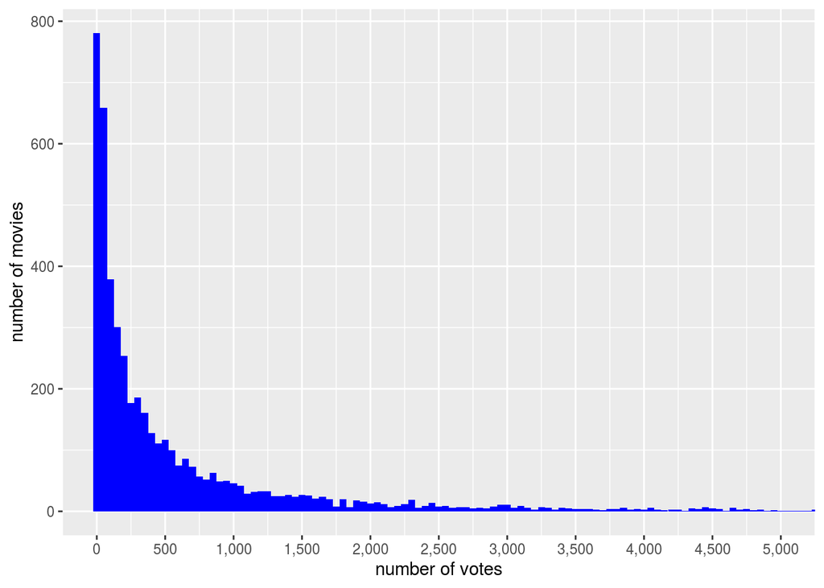

```r
movies %>%
        ggplot(aes(x=vote_count)) +
        geom_histogram(fill="blue", binwidth = 50) +
        scale_x_continuous(breaks=seq(0, 5000, by=500), label=comma) +
        coord_cartesian(x=c(0, 5000)) +
        labs(x="number of votes", y="number of movies")
```

### 3.1.2 Movies with the highest number of votes

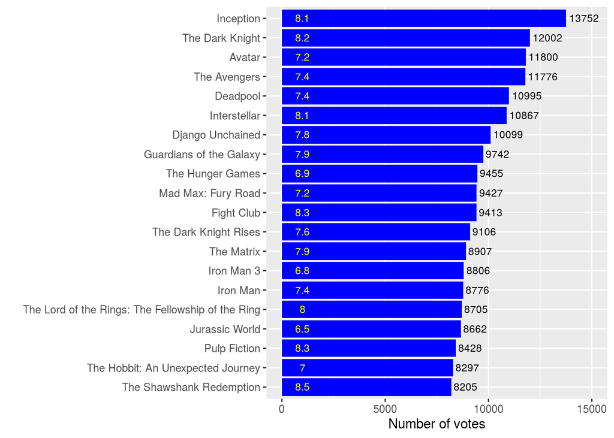

```r
movies  %>% top_n(20, wt=vote_count) %>%
        ggplot(aes(x=reorder(title, vote_count), y=vote_count)) +
        geom_bar(stat='identity', fill="blue") + coord_flip(y=c(0, 15000)) +
        labs(x="", y="Number of votes") +
        geom_text(aes(label=vote_count), hjust=-0.1, size=3) +
        geom_text(aes(label=vote_average), y=1000, size=3, col="yellow")
```

## 3.2 Vote average

### 3.2.1 Histogram of vote average

As you can see, the vote_average is left skewed, and the skew is -1.96.

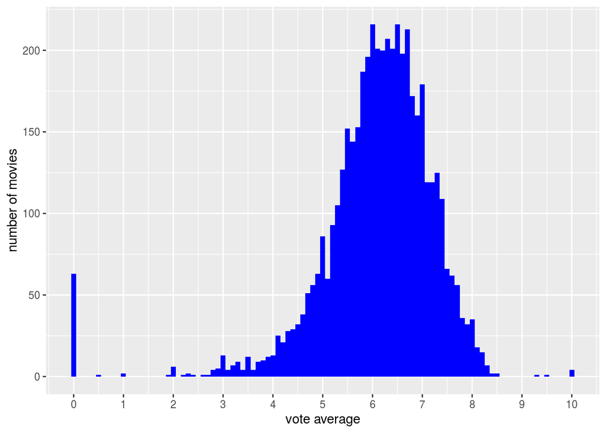

```r
movies %>%
        ggplot(aes(x=vote_average)) +
        geom_histogram(fill="blue", binwidth = 0.1) +
        scale_x_continuous(breaks=seq(0, 10, by=1)) +
        labs(x="vote average", y="number of movies")
```

However, we should realize that very high or very low vote_averages are generally based on small numbers of votes per movie. There are 62 movies with 0 votes and a vote_average of 0.0.

Below, I am filtering the movies on vote_average below 4.5 or above 8.5. As you can see, there are only 11 movies that “achieved” their vote_average in this range with at vote_count of at least 400.

```r
kable(movies %>% filter((vote_average<4.5|vote_average>8.5)& vote_count>=400) %>%
              select(id, title, vote_average, vote_count) %>% arrange(vote_average))
```

| id | title | vote_average | vote_count |
| --- | --- | --- | --- |
| 14164 | Dragonball Evolution | 2.9 | 462 |
| 205321 | Sharknado | 3.8 | 476 |
| 1639 | Speed 2: Cruise Control | 4.1 | 434 |
| 71880 | Jack and Jill | 4.1 | 604 |
| 241251 | The Boy Next Door | 4.1 | 1022 |
| 415 | Batman & Robin | 4.2 | 1418 |
| 314 | Catwoman | 4.2 | 808 |
| 166424 | Fantastic Four | 4.4 | 2278 |
| 188207 | The Legend of Hercules | 4.4 | 533 |
| 20533 | Jonah Hex | 4.4 | 420 |
| 87818 | Movie 43 | 4.4 | 797 |

### 3.2.2 Movies with the highest vote average

In this secton, I am displaying the top20 of movies with the highest vote_average that received at least 250 votes (first column, yellow numbers).

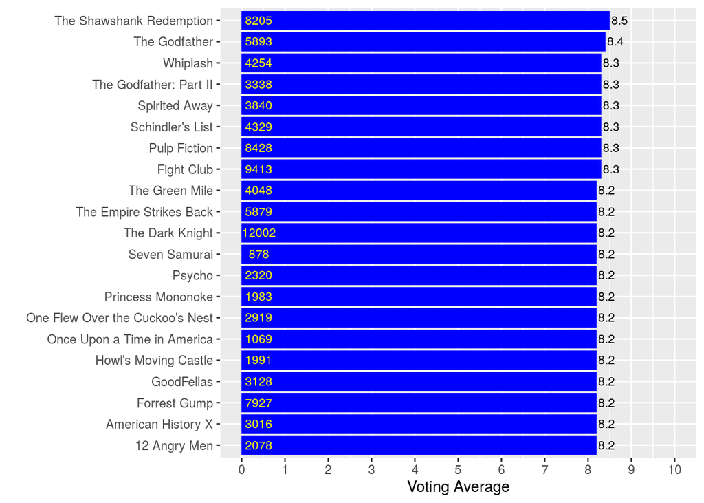

```r
movies %>% filter(vote_count > 250) %>% top_n(20, wt=vote_average) %>%
        ggplot(aes(x=reorder(title, vote_average), y=vote_average)) +
        geom_bar(stat='identity', fill="blue") + coord_flip(y=c(0,10)) +
        labs(x="", y="Voting Average") +
        geom_text(aes(label=vote_average), hjust=-0.1, size=3) +
        scale_y_continuous(breaks=seq(0, 10, by=1)) +
        geom_text(aes(label=vote_count), y=0.4, size=3, col="yellow")
```

## 3.3 Genres

### 3.3.1 Numbers of movies by genre

Please be aware that a movie can be labeled with multiple genres.

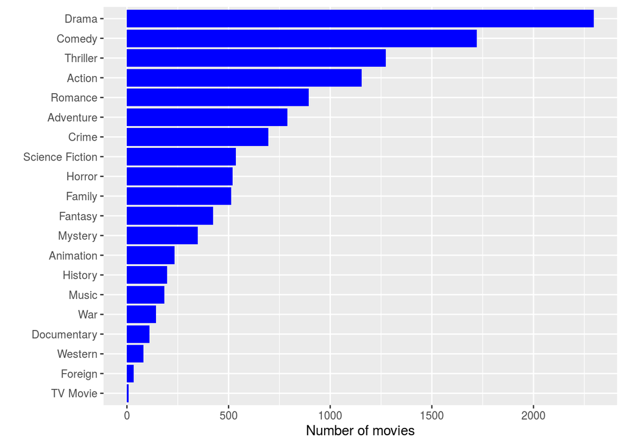

```r
genres %>% group_by(genres) %>% count() %>%
        ggplot(aes(x=reorder(genres, n), y=n)) +
        geom_col(fill="blue") + coord_flip() +
        labs(x="", y="Number of movies")
```

### 3.3.2 Highest rated movies by genre

In this section, I am displaying the Top10 of highest rated moves by genre. Again, I have only taken movies with at least 250 votes into consideration, and I am displaying all genres except the small genres “Foreign” and “TV movie”.

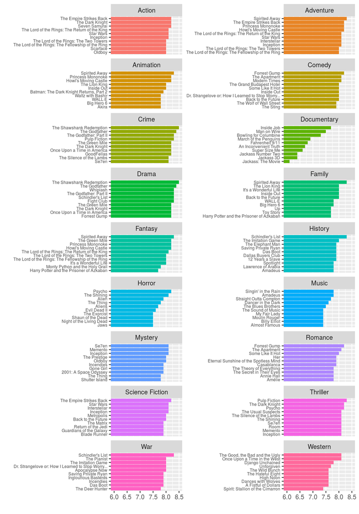

```r
genres250 <- left_join(genres, movies %>% filter(vote_count > 250) %>% select(id, vote_average, vote_count, original_language, original_title), by = "id")
genres250 <- genres250 %>% filter(!is.na(genres250$vote_average))
genres250$title <- str_trunc(as.character(genres250$title), width = 50, side="right")
genres250$title <- as.factor(genres250$title)

genres250 %>% filter(!genres %in% c("Foreign", "TV Movie")) %>%
        group_by(genres) %>% arrange(desc(vote_average)) %>% slice(1:10) %>%
        ggplot(aes(x=reorder(title, vote_average), y=vote_average)) +
        geom_col(aes(fill=genres), show.legend = FALSE) + coord_flip(y=c(6,8.5)) +
        facet_wrap(~genres, scales = "free_y", ncol=2) +
        labs(x="", y="") +
        theme(axis.text.y = element_text(size=6))
```

## 3.4 Popular actors and directors

### 3.4.1 Actors with most appearances

Below, you can find the 20 actors with most appearances.

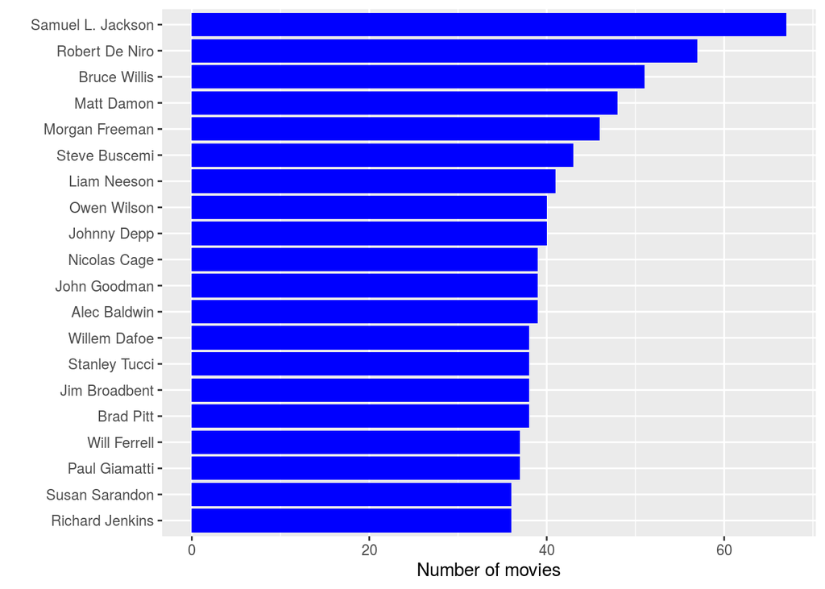

```r
cast1 %>% top_n(20, wt=n)%>%
        ggplot(aes(x=reorder(actor, n), y=n)) +
        geom_col(fill="blue") + coord_flip() +
        labs(x="", y="Number of movies")
```

#### 3.4.1.1 Top 10 profitable movies in TMDB

| title | profit |
| --- | --- |
| Avatar | 2,550,965,087 |
| Titanic | 1,645,034,188 |
| Jurassic World | 1,363,528,810 |
| Furious 7 | 1,316,249,360 |
| The Avengers | 1,299,557,910 |
| Avengers: Age of Ultron | 1,125,403,694 |
| Frozen | 1,124,219,009 |
| Minions | 1,082,730,962 |
| The Lord of the Rings: The Return of the King | 1,024,888,979 |
| Iron Man 3 | 1,015,439,994 |

## 3.5 Keywords

### 3.5.1 Number of distinct keywords in the database

Altogether, TMBD uses 9,813 keywords to describe its movies.

```r
n_distinct(keywords$keyword)
```

```
## [1] 9813
```

### 3.5.2 Most-used Keywords

You can find the Top-20 most-used keywords below. As I did not know what “during the credits stinger” was, I looked it up. Apparently, such a stinger (after or during the credits) is an extra/special scene.

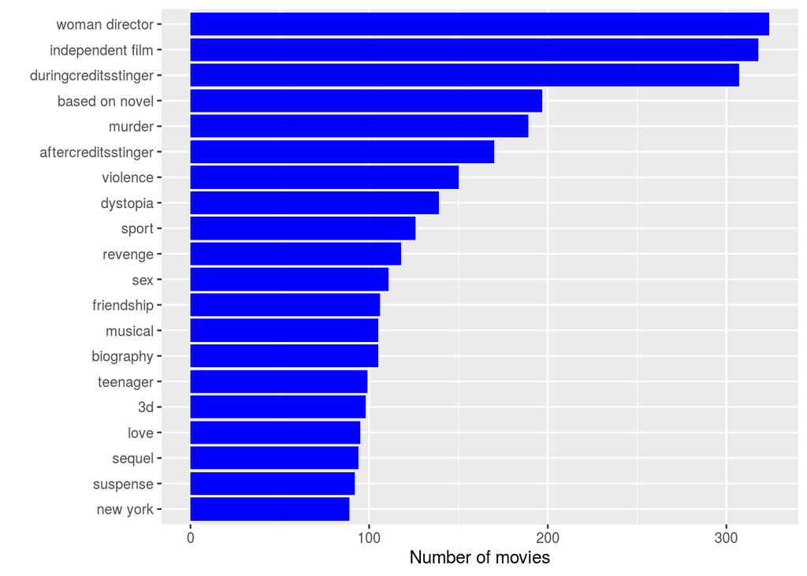

```r
keywords %>% count(keyword) %>% top_n(20, wt=n) %>%
        ggplot(aes(x=reorder(keyword, n), y=n)) +
        geom_col(fill="blue") + coord_flip() +
        labs(x="", y="Number of movies")
```

Below, you can find some more keywords in a wordcloud.

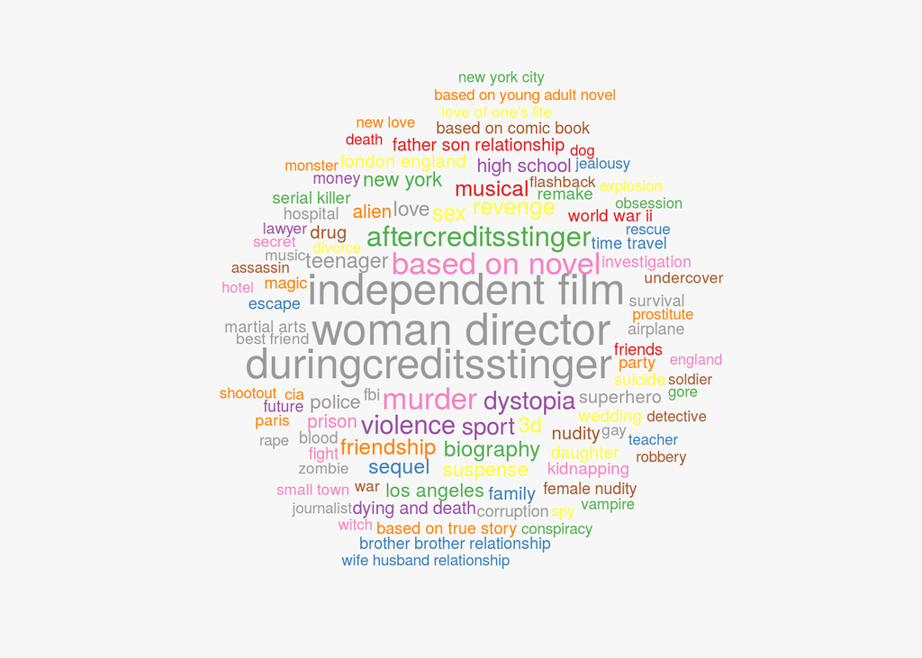

```r
set.seed(2019)

keywords_counts <- keywords %>% count(keyword)

par(mfrow=c(1, 1),bg="grey97")
wordcloud(keywords_counts$keyword, keywords_counts$n, max.words = 100, scale=c(2.0,.5), random.color = TRUE, random.order=FALSE, rot.per=0, colors=brewer.pal(9,"Set1"))
```

### 3.5.3 Histogram of the number of keywords per movie

There is a small number of outliers with lots of keywords.

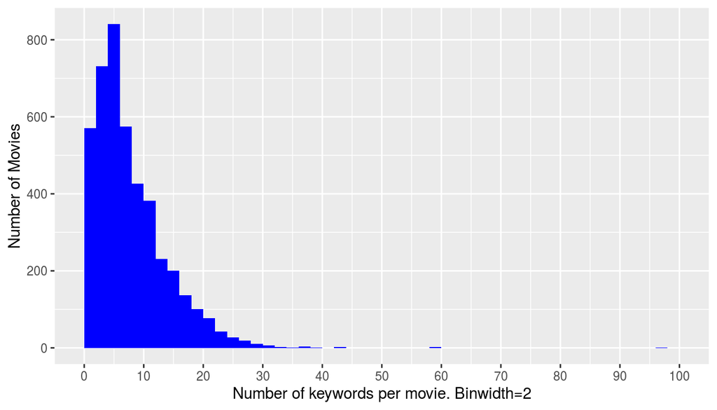

```r
dummy <- keywords %>% count(id, title)
dummy %>%
        ggplot() +
        geom_histogram(aes(x=n), breaks = seq(0, 100, by=2), fill="blue") +
        scale_x_continuous(breaks = seq(0, 100, by=10)) +
        labs(x="Number of keywords per movie. Binwidth=2", y= "Number of Movies")
```

# 4 Text analysis on tagline

Have you heard about these taglines? “Man is the warmest place to hide”. “Family isn’t a word. It’s a sentence”. These tagline are so memorable and precisely capture the spirit of the movie.

Let’s explore what are high frequency words the movie marketers would like to use. Tidy the “tagline” column in TMDB dataset.

## 4.1 High frequency words

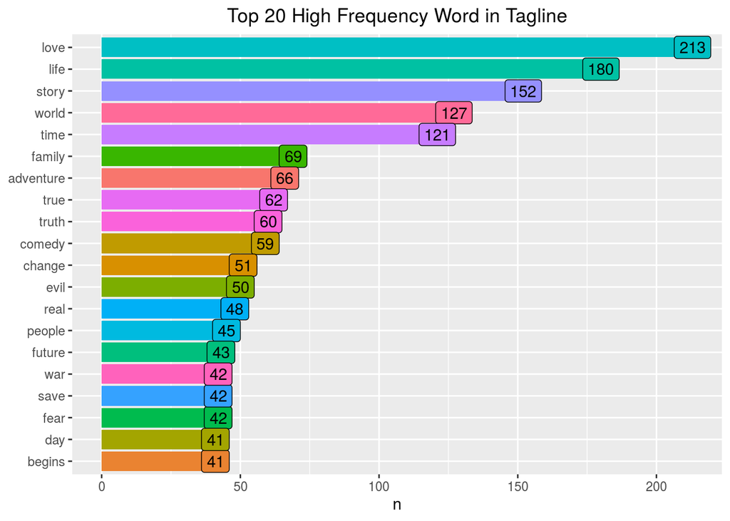

## 4.2 High frequency bi-grams

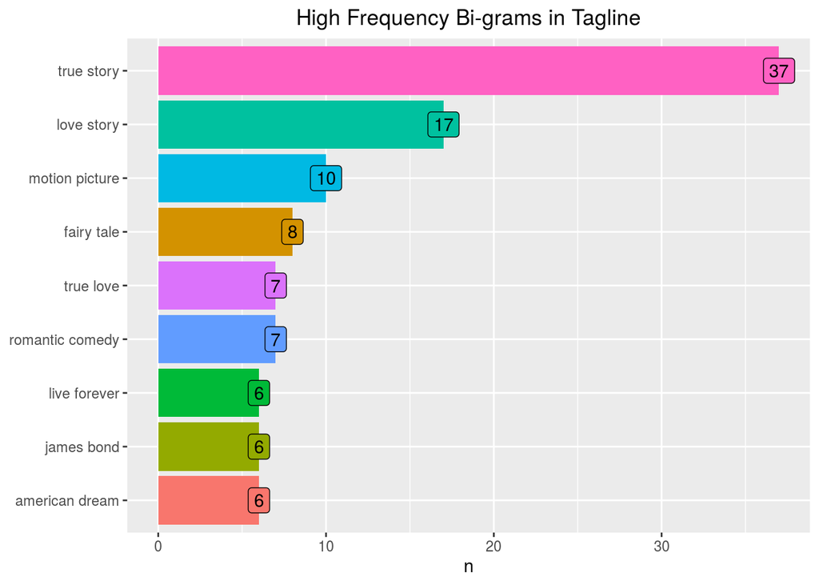

# 5 Explore production companies

Covert “production_companies” into data.frame similar to genre. Use the formattable package to achieve a better visualization.

I could provide a reasonable explanation for this: as independent films that become more popular, you don’t necessarily need big budgets to get big returns in the movie world. There are many good examples such as “Little Miss Sunshine”, “The King’s Speech”“,”Lost in Thailand".

```
## Warning: unnest() has a new interface. See ?unnest for details.
## Try `df %>% unnest(c(js, .name_repair))`, with `mutate()` if needed
```

### 5.0.1 Top 10 companies based on release

| company | count |
| --- | --- |
| Warner Bros. | 319 |
| Universal Pictures | 311 |
| Paramount Pictures | 285 |
| Twentieth Century Fox Film Corporation | 222 |
| Columbia Pictures | 201 |
| New Line Cinema | 165 |
| Metro-Goldwyn-Mayer (MGM) | 122 |
| Touchstone Pictures | 118 |
| Walt Disney Pictures | 114 |
| Relativity Media | 102 |

### 5.0.2 Top 10 companies based on revenue

| company | revenue (billion USD) |
| --- | --- |
| Pixar Animation Studios | 9.81 |
| Columbia Pictures Corporation | 9.35 |
| Revolution Sun Studios | 8.29 |
| TSG Entertainment | 8.19 |
| Ingenious Film Partners | 7.91 |
| Regency Enterprises | 7.58 |
| Jerry Bruckheimer Films | 7.21 |
| WingNut Films | 7.08 |
| Summit Entertainment | 6.93 |
| Lucasfilm | 6.61 |

### 5.0.3 Top 10 companies based on profit

[output not shown]

# 6 Deployment

Entire project is deployed on [GitHub](https://github.com/sagarjain1991/Data-Wrangling-and-Husbandry/tree/master/Final%20Project) with all the data files and acknowledgments.

Thanks!!